# FigureYa9 heatmap

Ying Ge; Yijing Chen

2025-5-20

## 需求描述

## requirement description

用R代码画出paper里的热图heatmap

Draw heatmap in paper with R code

## 使用场景

## usage scenario

场景一：sample间的相关性，用来评价生物学重复之间的重复性，或者体现不同组的差异

场景二：基因的表达变化聚类、sample聚类

Scenario 1: Correlation between samples, used to assess the reproducibility among biological replicates or to reflect differences between various groups.

Scenario 2: Clustering of Gene Expression Changes, Clustering of Samples

## 输入数据

## Input data

```r
df<-read.table("mRNA.txt",row.names = 1,header = T,as.is = T)
df[1:3,1:3]
```

```
##                    DG_01F DG_01M DG_04F
## ENSMMUG00000000001   1.19   1.02   0.88
## ENSMMUG00000000002   0.20   0.21   0.19
## ENSMMUG00000000004   0.00   0.01   0.00
```

```r
#查看一共有多少个基因，多少个sample
#check the number of genes and samples in total
dim(df)
```

```
## [1] 26654    64
```

## 开始画图

## Start drawing

### 场景一：sample间的相关性，用来评价生物学重复之间的重复性，或者不同组的差异

### Scenario 1: Correlation between samples, used to assess the reproducibility among biological replicates or to reflect differences between various groups

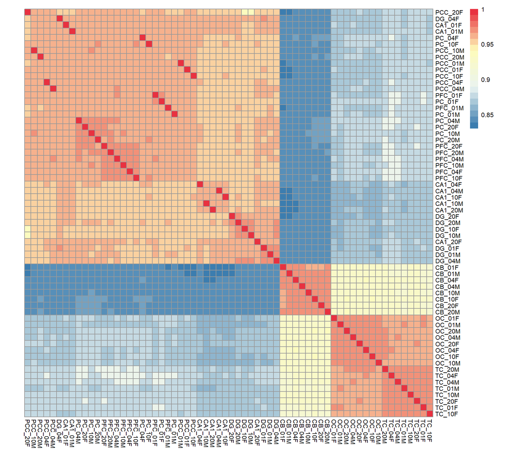

```r
#计算每两个sample之间的相关系数，method可选"pearson" (default), "kendall", or "spearman"
#calculate the correlation coefficient between each pair of samples, method can be "pearson" (default), "kendall", or "spearman"
cormat<-round(cor(df,method = "spearman"),2)

#install.packages("pheatmap")
library(pheatmap)
pheatmap(cormat,cellwidth = 8, cellheight = 8,fontsize = 8,
         color = colorRampPalette(c("#3C7DAF", "#EAF4F1","#FFFCBA", "#E83140"))(20),
         show_colnames=T,show_rownames =T,#显示sample的名字 display the name of the sample
         #border_color = "NA",#默认有边框，不要边框的话就加这行 the default is to have a border, add this line if you don't want a border
         treeheight_row = "0",treeheight_col = "0")#不画树 no tree drawing
```

输出pdf文件，只需加一行：filename=“文件名”

output pdf file, just add a line: filename=“filename”

```r
pheatmap(cormat,cellwidth = 8, cellheight = 8,fontsize = 8,
         #可以用下面这行自定义颜色
         #You can use the following line to define a custom color
         #color = colorRampPalette(c("#3C7DAF", "#EAF4F1","#FFFCBA", "#E83140"))(20),
         show_colnames=T,show_rownames =T,
         #border_color = "NA",#默认有边框，不要边框的话就加这行 the default is to have a border, add this line if you don't want a border
         treeheight_row = "0",treeheight_col = "0",
         filename="Correlation.pdf")
```

如果sample数量少，还可以在热图里显示数字

只需加一行：display_numbers = TRUE

If the sample size is small, you can also show the number in the heatmap

Just add one line: display_numbers = TRUE

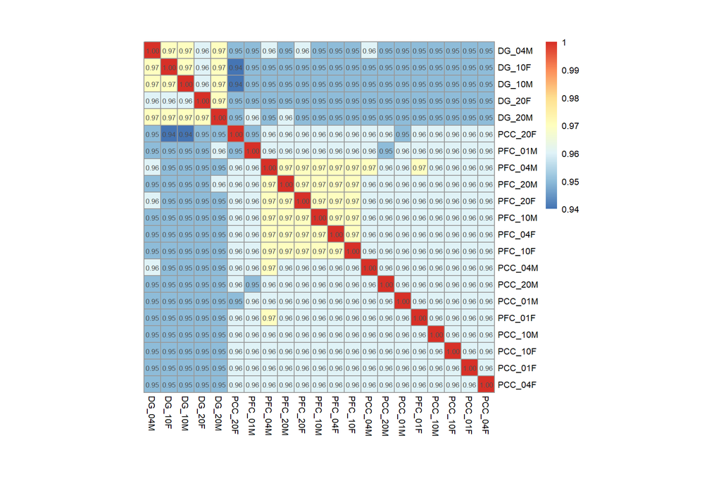

```r
pheatmap(cormat[4:24,4:24],cellwidth = 15, cellheight = 15,fontsize = 8,
         #color = colorRampPalette(c("#3C7DAF", "#EAF4F1","#FFFCBA", "#E83140"))(20),
         show_colnames=T,show_rownames =T,
         display_numbers = TRUE,#显示数字 display number
         treeheight_row = "0",treeheight_col = "0")#不画树 no tree drawing
```

有些热图，同组sample用同一个颜色表示，那些色块也是同时画出来的

要为每组设置颜色

For some heatmaps, the same group of samples is represented by the same color, and those color blocks are also drawn at the same time

set the color for each group

```r
#先查看有哪些sample，顺序是怎样的
#First check what samples are available and in what order
colnames(df)
```

```
##  [1] "DG_01F"  "DG_01M"  "DG_04F"  "DG_04M"  "DG_10F"  "DG_10M"  "DG_20F"
##  [8] "DG_20M"  "PFC_01F" "PFC_01M" "PFC_04F" "PFC_04M" "PFC_10F" "PFC_10M"
## [15] "PFC_20F" "PFC_20M" "PCC_01F" "PCC_01M" "PCC_04F" "PCC_04M" "PCC_10F"
## [22] "PCC_10M" "PCC_20F" "PCC_20M" "CA1_01F" "CA1_01M" "CA1_04F" "CA1_04M"
## [29] "CA1_10F" "CA1_10M" "CA1_20F" "CA1_20M" "CB_01F"  "CB_01M"  "CB_04F"
## [36] "CB_04M"  "CB_10F"  "CB_10M"  "CB_20F"  "CB_20M"  "OC_01F"  "OC_01M"
## [43] "OC_04F"  "OC_04M"  "OC_10F"  "OC_10M"  "OC_20F"  "OC_20M"  "TC_01F"
## [50] "TC_01M"  "TC_04F"  "TC_04M"  "TC_10F"  "TC_10M"  "TC_20F"  "TC_20M"
## [57] "PC_01F"  "PC_01M"  "PC_04F"  "PC_04M"  "PC_10F"  "PC_10M"  "PC_20F"
## [64] "PC_20M"
```

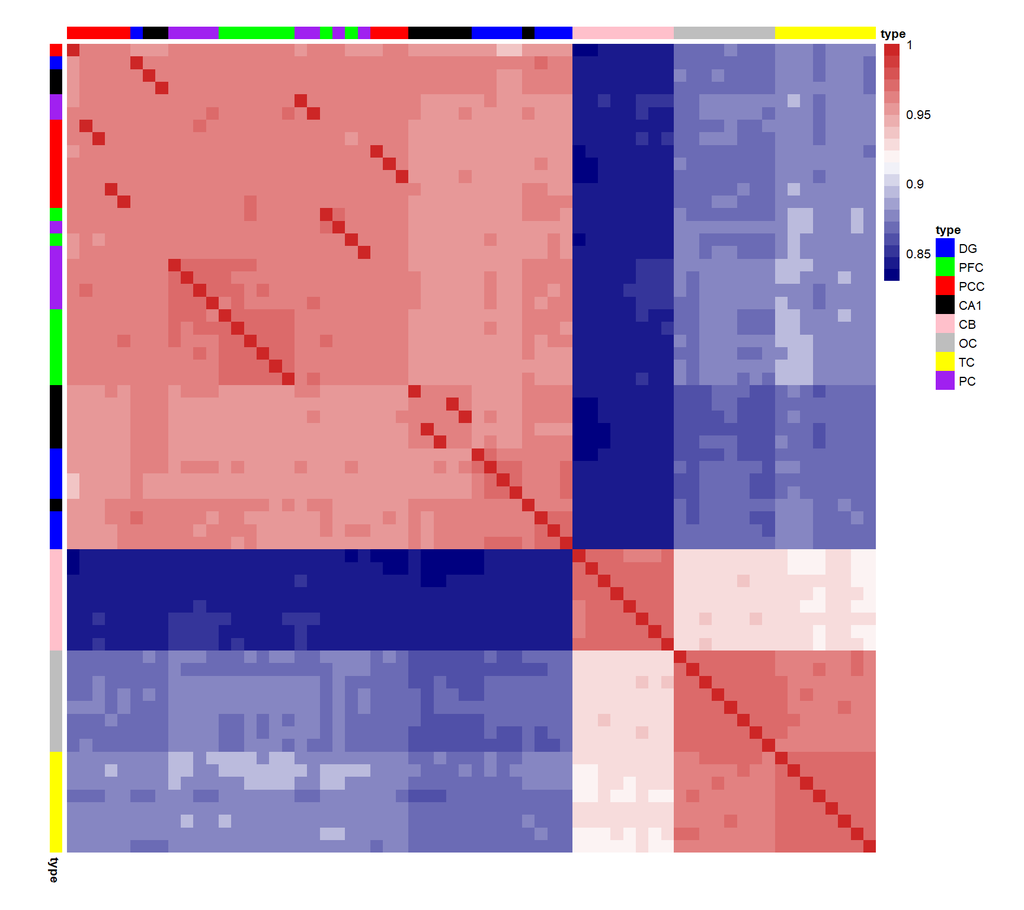

```r
#按照sample的顺序，告诉R，它是属于哪个组的
#Tell R, in order of sample, which group it belongs to
annotation_col = data.frame(
  type = factor(rep(c("DG","PFC","PCC","CA1","CB","OC","TC","PC"),c(8,8,8,8,8,8,8,8))))
rownames(annotation_col) = colnames(df)

annotation_row = data.frame(
  type = factor(rep(c("DG","PFC","PCC","CA1","CB","OC","TC","PC"),c(8,8,8,8,8,8,8,8))))
rownames(annotation_row) = colnames(df)

#然后给每个组设置颜色
#then set the color for each group
ann_colors = list(
  type = c(DG = "blue", PFC = "green", PCC = "red", CA1 = "black",
  CB = "pink", OC = "grey", TC = "yellow", PC = "purple")
)

pheatmap(cormat,cellwidth = 8, cellheight = 8,
         fontsize = 8,
         #display_numbers = TRUE,
         color = colorRampPalette(c("navy", "white", "firebrick3"))(20),
         show_colnames=F,show_rownames =F,#不显示sample的名字 do not show the name of the sample
         annotation_col = annotation_col, annotation_row = annotation_row,
         annotation_colors = ann_colors,
         treeheight_row = "0",treeheight_col = "0",#不画树 no tree drawing
         border_color = "NA")#不显示边框 do not show border
```

### 场景二：基因的表达变化聚类、sample聚类

### Scenario 2: Clustering of Gene Expression Changes, Clustering of Samples

```r
library(pheatmap)
#有时会有多种分组方式，那就分别告诉R，此处增加一个性别组
#sometimes there are multiple groupings, so tell R separately and add a gender group here
annotation_col <- data.frame(
  Gender = factor(rep(c("F","M"),32)),#按性别分组 group by gender
  type = factor(rep(c("DG","PFC","PCC","CA1","CB","OC","TC","PC"),c(8,8,8,8,8,8,8,8))))
rownames(annotation_col) = colnames(df)

ann_colors = list(
  Gender = c(F = "#FFA42D", M = "#A9D9DF"),#给性别分组设置颜色 set colors for gender grouping
  type = c(DG = "blue", PFC = "green", PCC = "red", CA1 = "black",
  CB = "pink", OC = "grey", TC = "yellow", PC = "purple")
)

#此处用前1000行基因画图
#实际作图时，先筛差异基因，再用差异基因画图；或者用变化大的Top几千个基因画图
#here the first 1000 rows of genes are used to draw the graph
#When creating the plot, first filter the differential genes and then use them for plotting; alternatively, use the top few thousand genes with the most significant changes for plotting.
deg <- df[1:1000,]
pheatmap(deg, cellwidth = 8, cellheight = 1, fontsize = 8,
         method="spearman", #计算gene或sample之间的相关性的方法，可选"pearson" method to calculate correlation between genes or samples, optionally “pearson”. (default), "kendall", or "spearman"
         scale="row", #为基因做scale scale for genes
         cluster_rows=T, #为基因做聚类 cluster for genes
         cluster_cols=T, #为sample做聚类 cluster for sample
         color = colorRampPalette(c("navy", "white", "firebrick3"))(20), #自定义颜色 custom color
         show_colnames=F, #显示样品名称就改为T display sample name and change it to T
         show_rownames =F, #显示基因名就改为T display the gene name and change it to T
         annotation_col = annotation_col,
         annotation_colors = ann_colors,
         #如果想显示树状结构，就删掉下面这行前面的#
         #If you want to show the tree structure, just delete the line below#
         #treeheight_row = "0",treeheight_col = "0",#不画树 no tree drawing
         filename = "pheatmap.pdf", #直接保存到pdf文件 save directly to pdf file
         border_color = "NA") #不给每个小格子画边框，如果画边框，可以把NA改为你想要的颜色
#Do not draw borders for each cubby, if you do, you can change the NA to the color you want
```

[figure not shown]